# Análise Fatorial

Ricardo Limongi

2025-03-18

# 1 Introdução

A **Análise Fatorial** é uma técnica estatística usada para reduzir a dimensionalidade de um conjunto de variáveis, identificando fatores latentes que explicam suas correlações. Vamos discutir**dois exemplos**:

1. **Análise Fatorial Exploratória (AFE) em dados contínuos e ordinais**
2. **Análise Fatorial Confirmatória (AFC) para ambos os tipos de dados**

**Atenção** É fundamental fazer a análiose considerando a natureza do dado cletado.

## 1.1 Exemplo 1: Análise Fatorial Exploratória (AFE) em Dados Contínuos

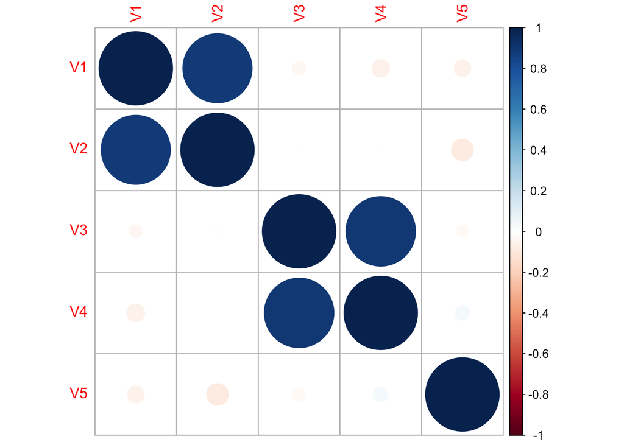

```r
# Gerando um conjunto de dados fictício com variáveis correlacionadas
set.seed(123)
n <- 200  # Número de observações
dados_continuos <- data.frame(
  V1 = rnorm(n, mean = 50, sd = 10),
  V2 = rnorm(n, mean = 50, sd = 10),
  V3 = rnorm(n, mean = 50, sd = 10),
  V4 = rnorm(n, mean = 50, sd = 10),
  V5 = rnorm(n, mean = 50, sd = 10)
)

# Criar correlações artificiais entre algumas variáveis
dados_continuos$V2 <- dados_continuos$V1 + rnorm(n, 0, 5)
dados_continuos$V4 <- dados_continuos$V3 + rnorm(n, 0, 5)

# Matriz de correlação
corrplot(cor(dados_continuos), method = "circle")
```

### 1.1.1 Aplicando a Análise Fatorial Exploratória (AFE)

```r
# Determinar a adequação dos dados
KMO(dados_continuos)  # Teste de Kaiser-Meyer-Olkin (idealmente > 0.6)
```

```
## Kaiser-Meyer-Olkin factor adequacy
## Call: KMO(r = dados_continuos)
## Overall MSA =  0.47
## MSA for each item =
##   V1   V2   V3   V4   V5
## 0.48 0.48 0.48 0.47 0.15
```

```r
# Teste de esfericidade de Bartlett (deve ser significativo)
cortest.bartlett(cor(dados_continuos), n)
```

```
## $chisq
## [1] 634.1546
##
## $p.value
## [1] 8.414476e-130
##
## $df
## [1] 10
```

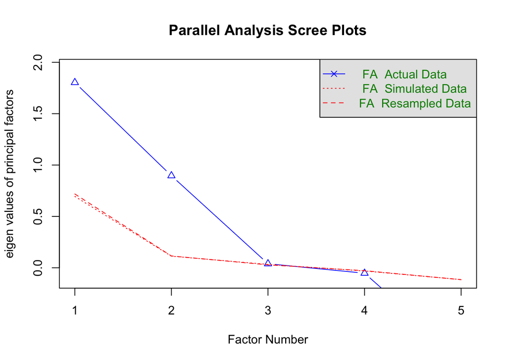

```
## Parallel analysis suggests that the number of factors =  2  and the number of components =  NA
```

```r
# Determinar o número de fatores pelo critério de eigenvalues
fa.parallel(dados_continuos, fa = "fa", n.iter = 100)
```

```r
# Executar a AFE
afe <- fa(dados_continuos, nfactors = 2, rotate = "varimax", fm = "ml")
print(afe$loadings, cutoff = 0.4) # Exibir cargas fatoriais relevantes
```

```
##
## Loadings:
##    ML1    ML2
## V1         0.889
## V2         0.996
## V3  0.897
## V4  0.996
## V5
##
##                 ML1   ML2
## SS loadings    1.80 1.797
## Proportion Var 0.36 0.359
## Cumulative Var 0.36 0.719
```

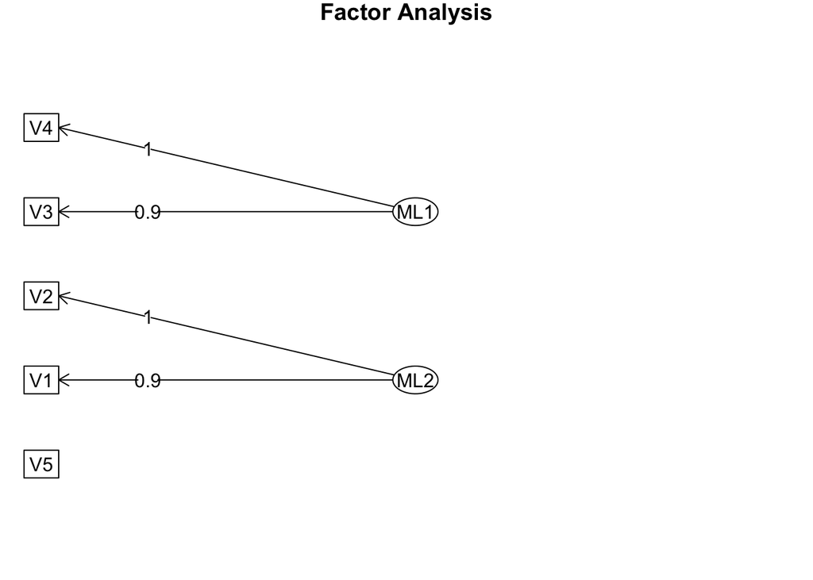

```r
# Visualizar a matriz de cargas fatoriais
fa.diagram(afe)
```

# 2 Interpretação

Teste de Bartlett: Com p-valorbaixo (8.41e-130), rejeitamos a hipótese nula de que a matriz de correlação é uma matriz identidade, confirmando que existem correlações significativas entre as variáveis.

Extração de Fatores

Análise Paralela: Sugeriu 2 fatores, o que foi adotado.

Cargas Fatoriais: - Fator 1 (ML1): V3 (0.897) e V4 (0.996) apresentam cargas altas - Fator 2 (ML2): V1 (0.889) e V2 (0.996) apresentam cargas altas - V5 não apresentou carga significativa em nenhum fator

Variância Explicada: Os dois fatores explicam cerca de 71.9% da variância total, o que é um bom resultado, porém, é sempre importante consultar a literatura da área para comparação da variância aceita.

Interpretação dos Fatores O diagrama mostra dois grupos distintos: - O primeiro fator (ML1) está fortemente associado a V3 e V4 - O segundo fator (ML2) está fortemente associado a V1 e V2

A estrutura faz sentido considerando que os dados foram gerados com correlações específicas entre V1-V2 e V3-V4.

## 2.1 Exemplo 2: Análise Fatorial Exploratória (AFE) para Dados Ordinais

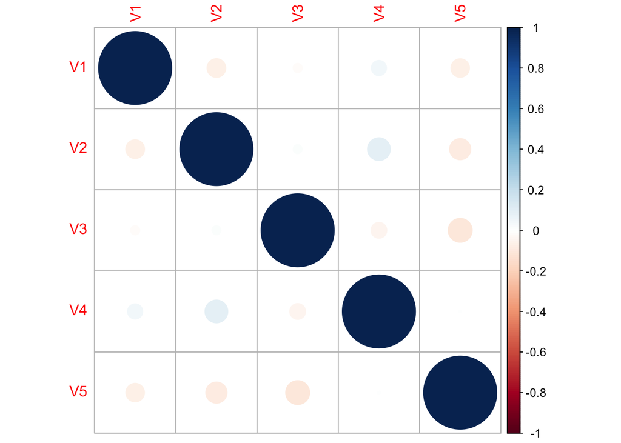

```r
# Criando um dataset simulado com escala Likert (1 a 5)
set.seed(123)
dados_ordin <- data.frame(
  V1 = sample(1:5, n, replace = TRUE),
  V2 = sample(1:5, n, replace = TRUE),
  V3 = sample(1:5, n, replace = TRUE),
  V4 = sample(1:5, n, replace = TRUE),
  V5 = sample(1:5, n, replace = TRUE)
)

# Matriz de correlação policórica
cor_pol <- hetcor(dados_ordin)$correlations
corrplot(cor_pol, method = "circle")
```

```r
# AFE com correlações policóricas
afe_ord <- fa(cor_pol, nfactors = 2, rotate = "varimax", fm = "ml")
print(afe_ord$loadings, cutoff = 0.4)
```

```
##
## Loadings:
##    ML1    ML2
## V1
## V2         0.993
## V3
## V4
## V5  0.997
##
##                  ML1   ML2
## SS loadings    1.020 1.001
## Proportion Var 0.204 0.200
## Cumulative Var 0.204 0.404
```

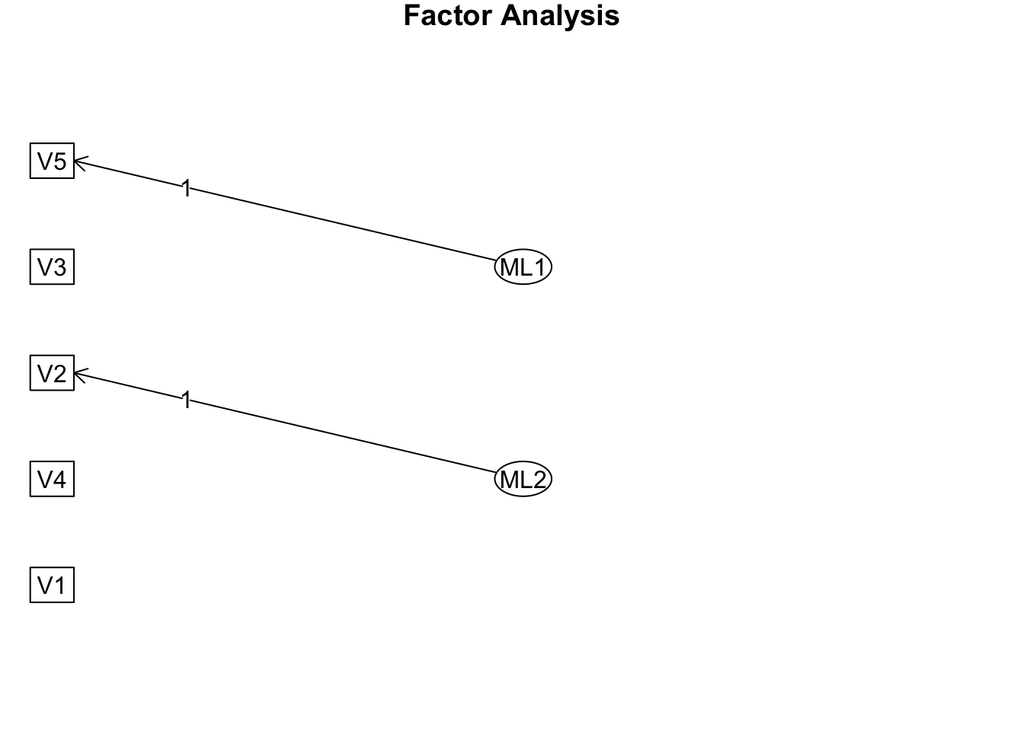

```r
fa.diagram(afe_ord)
```

# 3 Matriz de Correlação Policórica

A matriz de correlação mostra que, para os dados ordinais, as variáveis apresentam um padrão diferente, com correlações mais dispersas.

Extração de Fatores: Foram extraídos 2 fatores, conforme decidido previamente.

Cargas Fatoriais: - Fator 1 (ML1): V5 (0.997) apresenta carga alta - Fator 2 (ML2): V2 (0.993) apresenta carga alta - V1, V3 e V4 não apresentaram cargas significativas

Variância Explicada: Os dois fatores explicam apenas 40.4% da variância total, o que é moderado.

## 3.1 Exemplo 3: Análise Fatorial Confirmatória (AFC) para Ambos os Tipos de Dados

```r
# Modelo teórico baseado nos resultados da AFE
modelo_afc <- '
F1 =~ V1 + V2 + V3
F2 =~ V4 + V5
'

# Ajustar modelo no lavaan para dados contínuos
afcm_cont <- cfa(modelo_afc, data = dados_continuos)
summary(afcm_cont, fit.measures = TRUE, standardized = TRUE)
```

```
## lavaan 0.6-19 ended normally after 2968 iterations
##
##   Estimator                                         ML
##   Optimization method                           NLMINB
##   Number of model parameters                        11
##
##   Number of observations                           200
##
## Model Test User Model:
##
##   Test statistic                               331.183
##   Degrees of freedom                                 4
##   P-value (Chi-square)                           0.000
##
## Model Test Baseline Model:
##
##   Test statistic                               645.450
##   Degrees of freedom                                10
##   P-value                                        0.000
##
## User Model versus Baseline Model:
##
##   Comparative Fit Index (CFI)                    0.485
##   Tucker-Lewis Index (TLI)                      -0.287
##
## Loglikelihood and Information Criteria:
##
##   Loglikelihood user model (H0)              -3585.869
##   Loglikelihood unrestricted model (H1)      -3420.277
##
##   Akaike (AIC)                                7193.738
##   Bayesian (BIC)                              7230.019
##   Sample-size adjusted Bayesian (SABIC)       7195.170
##
## Root Mean Square Error of Approximation:
##
##   RMSEA                                          0.640
##   90 Percent confidence interval - lower         0.582
##   90 Percent confidence interval - upper         0.699
##   P-value H_0: RMSEA <= 0.050                    0.000
```

[output cut: 21 more lines]

```
##
## Covariances:
##                    Estimate    Std.Err  z-value  P(>|z|)   Std.lv    Std.all
##   F1 ~~
##     F2                  0.129       NA                        0.040    0.040
##
## Variances:
##                    Estimate    Std.Err  z-value  P(>|z|)   Std.lv    Std.all
##    .V1                 88.056       NA                       88.056    0.994
##    .V2             -15172.077       NA                   -15172.077 -120.449
##    .V3                 92.604       NA                       92.604    1.000
##    .V4                137.816       NA                      137.816    1.159
##    .V5                107.673       NA                      107.673    1.010
##     F1                  0.547       NA                        1.000    1.000
##     F2                -18.906       NA                           NA       NA
```

```r
# Ajustar modelo no lavaan para dados ordinais (usando WLSMV)
afcm_ord <- cfa(modelo_afc, data = dados_ordin, ordered = colnames(dados_ordin))
summary(afcm_ord, fit.measures = TRUE, standardized = TRUE)
```

```
## lavaan 0.6-19 did NOT end normally after 450 iterations
## ** WARNING ** Estimates below are most likely unreliable
##
##   Estimator                                       DWLS
##   Optimization method                           NLMINB
##   Number of model parameters                        26
##
##   Number of observations                           200
##
##
## Parameter Estimates:
##
##   Parameterization                               Delta
##   Standard errors                           Robust.sem
##   Information                                 Expected
##   Information saturated (h1) model        Unstructured
##
## Latent Variables:
##                    Estimate    Std.Err  z-value  P(>|z|)   Std.lv    Std.all
##   F1 =~
##     V1                  1.000                               146.336    146.336
##     V2                 -0.000       NA                       -0.001     -0.001
##     V3                 -0.000       NA                       -0.000     -0.000
##   F2 =~
##     V4                  1.000                                    NA         NA
##     V5                 -1.335       NA                           NA         NA
##
## Covariances:
##                    Estimate    Std.Err  z-value  P(>|z|)   Std.lv    Std.all
##   F1 ~~
##     F2                  0.055       NA                        0.010      0.010
##
## Thresholds:
##                    Estimate    Std.Err  z-value  P(>|z|)   Std.lv    Std.all
##     V1|t1              -0.739       NA                       -0.739     -0.739
##     V1|t2              -0.176       NA                       -0.176     -0.176
##     V1|t3               0.292       NA                        0.292      0.292
##     V1|t4               0.789       NA                        0.789      0.789
##     V2|t1              -0.878       NA                       -0.878     -0.878
##     V2|t2              -0.228       NA                       -0.228     -0.228
```

[output cut: 9 more lines]

```
##     V4|t4               0.878       NA                        0.878      0.878
##     V5|t1              -0.842       NA                       -0.842     -0.842
##     V5|t2              -0.332       NA                       -0.332     -0.332
##     V5|t3               0.189       NA                        0.189      0.189
##     V5|t4               0.772       NA                        0.772      0.772
##
## Variances:
##                    Estimate    Std.Err  z-value  P(>|z|)   Std.lv    Std.all
##    .V1             -21413.107                            -21413.107 -21413.107
##    .V2                  1.000                                 1.000      1.000
##    .V3                  1.000                                 1.000      1.000
##    .V4                  1.002                                 1.002      1.002
##    .V5                  1.003                                 1.003      1.003
##     F1              21414.107       NA                        1.000      1.000
##     F2                 -0.002       NA                           NA         NA
```

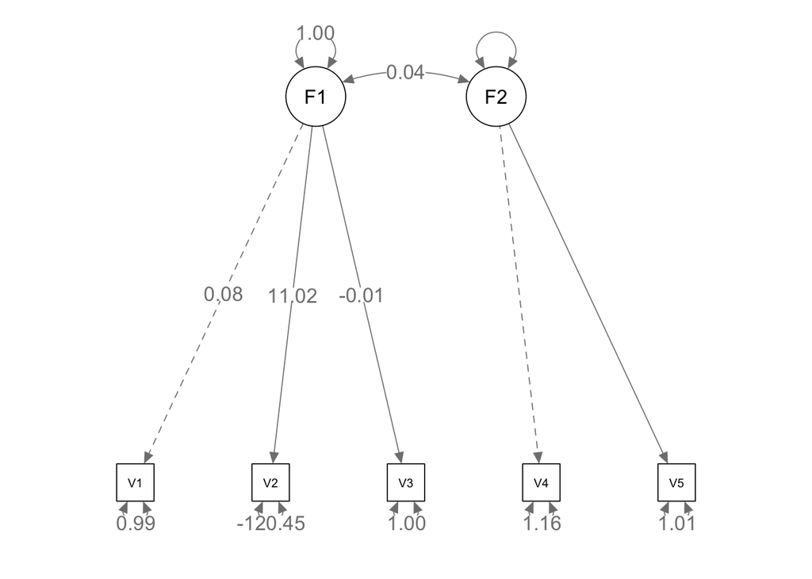

```r
# Visualização do modelo fatorial
semPaths(afcm_cont, whatLabels = "std", layout = "tree", edge.label.cex = 1.2)
```

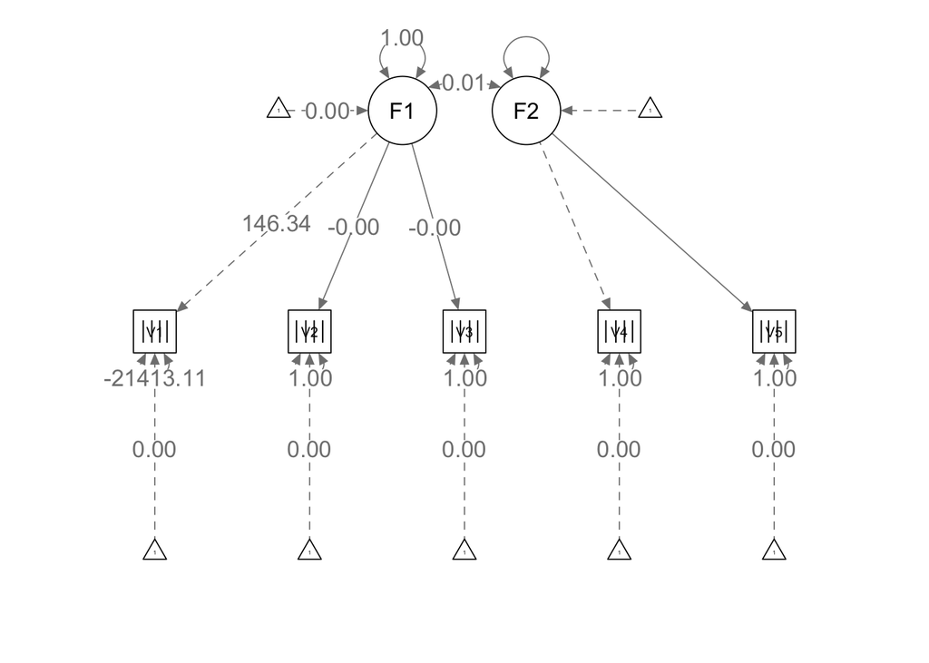

```r
semPaths(afcm_ord, whatLabels = "std", layout = "tree", edge.label.cex = 1.2)
```

## 3.2 Dados Contínuos

Modelo: F1 =~ V1 + V2 + V3; F2 =~ V4 + V5 Ajuste do Modelo:

χ² = 331.183 (df = 4, p < 0.001) - significativo, o que não é ideal CFI = 0.485 - muito abaixo do aceitável (deveria ser > 0.90) TLI = -0.287 - valor negativo é preocupante RMSEA = 0.640 - muito acima do aceitável (deveria ser < 0.08) SRMR = 0.241 - muito acima do aceitável (deveria ser < 0.08)

Dados Ordinais: o modelo não convergiu após 450 iterações, o que indica problemas no ajuste. Os avisos “Warning” mostram que:

- Não foi possível calcular erros padrão
- Algumas variâncias estimadas são negativas

Interpretação da AFC Os modelos apresentaram problemas de ajuste. Sugere que o modelo teórico proposto não se ajusta bem aos dados, o que é esperado para os dados ordinais (já que foram gerados aleatoriamente). Para os dados contínuos, o problema pode estar relacionado ao fato de que a estrutura fatorial da AFE não colocou V3 junto com V1 e V2 como definido no modelo AFC.

# 4 Conclusão

# 5 Reflexão e Caminhos para Análise de Dados

1. Refinamento do Modelo

Especificação do Modelo: Revisar o modelo teórico com base nos resultados da AFE Modificações de Índices: Considerar os índices de modificação para melhorar o ajuste do modelo Covariâncias entre Erros: Permitir covariâncias entre erros quando há justificativa teórica

2. Abordagens Alternativas

3. Diagnóstico Aprofundado

Análise Residual: Examinar os resíduos para identificar fontes específicas de desajuste Análise de Comunalidades: Verificar se algumas variáveis têm comunalidades baixas Identificação de Outliers: Verificar se existem observações extremas afetando os resultados

4. Validação Cruzada

Divisão da Amostra: Dividir a amostra em treinamento e teste para validar a estrutura fatorial Amostras Independentes: Se possível, replicar a análise em amostras independentes

5. Interpretação Substantiva

Significado dos Fatores: Interpretar os fatores identificados em termos substantivos Escores Fatoriais: Calcular e utilizar escores fatoriais para análises subsequentes Validade de Construto: Examinar a relação dos fatores com variáveis externas

6. Considerações Metodológicas

Para dados contínuos, a AFE funcionou bem, mas a AFC apresentou problemas Para dados ordinais, tanto a AFE quanto a AFC tiveram limitações Considerar métodos alternativos como Análise de Componentes Principais (PCA) ou técnicas de redução de dimensionalidade não lineares (como t-SNE ou UMAP)

7. Verificação dos Pressupostos

Verificar a normalidade multivariada dos dados Testar a presença de multicolinearidade Examinar a linearidade das relações entre variáveis